# Exploratory Data Analysis of ISPARK Dataset

## Dataset

We have two tables in our dataset. First table contains information about ISPARK park areas. Second table contains hourly percentage of occupancy of these park areas between 19 November 2020 and 2 December 2020. We have collected this datas by using IBB Open Data API. You can also access this API from [here.](https://api.ibb.gov.tr/ispark/Park)

### Park Informations Table

Park Information table contains 9 variables and 577 observations. Descriptions of columns is below.

- `ParkID`: Unique identifier of the parking place
- `ParkAdi`: Name of the parking place
- `Latitude`: Latitude of the parking place
- `Longitude`: Longitude of the parking place
- `Kapasitesi`: Full capacity of the parking space when it is empty
- `ParkTipi`: Types of parking ways of the parking space; Yolüstü – Acik– Kapali
- `Ilce`: District which parking space in
- `UcretsizParklanmaDk`:Free parking duration in minutes
- `AylıkAbonelikUcreti`:Monthly subscription fee (₺)

#### Summary of Dataset

```
##      ParkID       ParkAdi            Latitude          Longitude
##  Min.   :   1   Length:577         Length:577         Length:577
##  1st Qu.: 561   Class :character   Class :character   Class :character
##  Median :1259   Mode  :character   Mode  :character   Mode  :character
##  Mean   :1273
##  3rd Qu.:1960
##  Max.   :2866
##    Kapasitesi       ParkTipi             Ilce           UcretsizParklanmaDk
##  Min.   :   5.0   Length:577         Length:577         Min.   :  0.00
##  1st Qu.:  30.0   Class :character   Class :character   1st Qu.:  5.00
##  Median :  50.0   Mode  :character   Mode  :character   Median : 15.00
##  Mean   : 189.8                                         Mean   : 11.18
##  3rd Qu.: 120.0                                         3rd Qu.: 15.00
##  Max.   :5000.0                                         Max.   :120.00
##  AylikAbonelikÜcreti
##  Min.   :  0.0
##  1st Qu.:  0.0
##  Median :180.0
##  Mean   :158.2
##  3rd Qu.:240.0
##  Max.   :500.0
```

### Hourly Percentage of Occupancy Table

Hourly Percentage of Occupancy table contains 4 variables and 178984 observations. Descriptions of columns is below.

- `ParkID`: Unique identifier of the parking place
- `ParkAdi`: Name of the parking place
- `DolulukYuzdesi`: Percentage of occupancy
- `OlcumZamanı`: Observation date and time

#### Summary of Dataset

```
##      ParkID       ParkAdi          DolulukYuzdesi
##  Min.   :   1   Length:178984      Min.   :  0.00
##  1st Qu.: 547   Class :character   1st Qu.: 56.67
##  Median :1259   Mode  :character   Median : 82.00
##  Mean   :1268                      Mean   : 73.72
##  3rd Qu.:1958                      3rd Qu.:100.00
##  Max.   :2866                      Max.   :100.00
##   OlcumZamani
##  Min.   :2020-11-18 23:35:01
##  1st Qu.:2020-11-22 02:00:02
##  Median :2020-11-25 08:00:02
##  Mean   :2020-11-25 08:21:09
##  3rd Qu.:2020-11-28 14:00:01
##  Max.   :2020-12-01 22:00:02
```

### Missing Values

We don’t have any missing values in our tables as you can see below. We think this is because we use API data that is cleaned and submitted by others.

Missing values in Park Information table by variable

```
##              ParkID             ParkAdi            Latitude           Longitude
##                   0                   0                   0                   0
##          Kapasitesi            ParkTipi                Ilce UcretsizParklanmaDk
##                   0                   0                   0                   0
## AylikAbonelikÜcreti
##                   0
```

Missing values in Hourly Percentage of Occupancy table by variable

```
##         ParkID        ParkAdi DolulukYuzdesi    OlcumZamani
##              0              0              0              0
```

## Statistical Examination

### Park Type Summary Table

According to their types, we can see the count, total capacity and avg. monthly price in below table.

```
## # A tibble: 5 x 6
## # Groups:   ParkTipi [5]
##   ParkTipi `Park Adeti` `Toplam Kapasit~ `Ortalama Kapat~ `Ortalama Ücret~
##   <chr>           <int>            <int>            <dbl>            <dbl>
## 1 YOL ÜSTÜ          349            14128             40.5            12.5
## 2 AÇIK OT~          163            71394            438               8.99
## 3 KAPALI ~           53            23608            445.             11.8
## 4 TAKSI P~           11              272             24.7             0
## 5 MINIBÜS~            1              100            100               0
## # ... with 1 more variable: `Ortalama Aylik Ücret` <dbl>
```

### Park Count by District

Top 10 district who has most park count are as follows;

```
## # A tibble: 33 x 2
## # Groups:   Ilce [33]
##    Ilce         n
##    <chr>    <int>
##  1 FATIH      100
##  2 BESIKTAS    64
##  3 SISLI       64
##  4 BAKIRKÖY    38
##  5 KADIKÖY     38
##  6 BEYOGLU     29
##  7 SARIYER     27
##  8 PENDIK      23
##  9 ÜSKÜDAR     19
## 10 ATASEHIR    18
## # ... with 23 more rows
```

### Boxplot of Avg. monthly price for each type of `Park Type`

We took out 2 of the park types because their quantity was lower than the others so they were misleading. In conclusion, * ‘Open Park’ has a lower mean of monthly price than ‘Close Park’ and ‘Road Park’. * Close Park’s monthly price has outliers. But despite those outliers, its monthly prices varies the least.

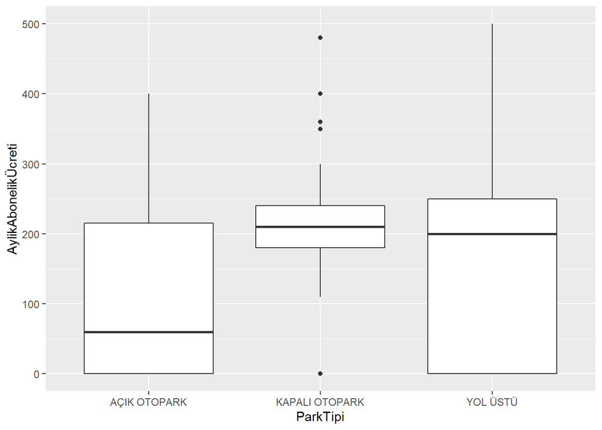

### Hourly Occupancy Rates

The line graph below shows us average hourly occupancy rates of ‘Ispark’ stations. It can be seen from the graph that average parking occupancy rate during daytime is less than nights. Parking occupancy rate is starting to decrease when working hours started and continue to decrease until approximately 15:00 pm. and it sharply increases by closing hours of working day. The graph shows that ‘Ispark’ stations mostly used during night.

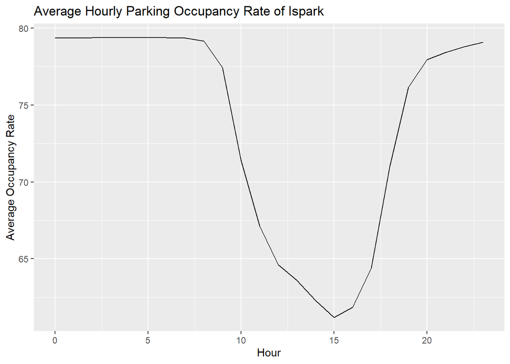

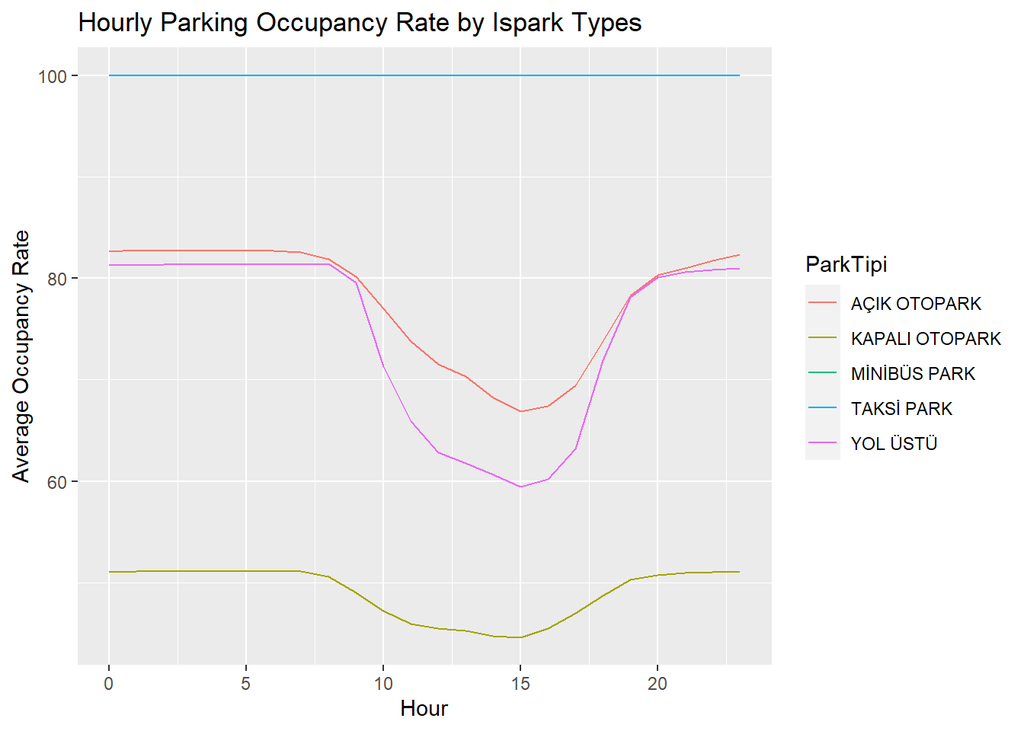

### Price Histogram

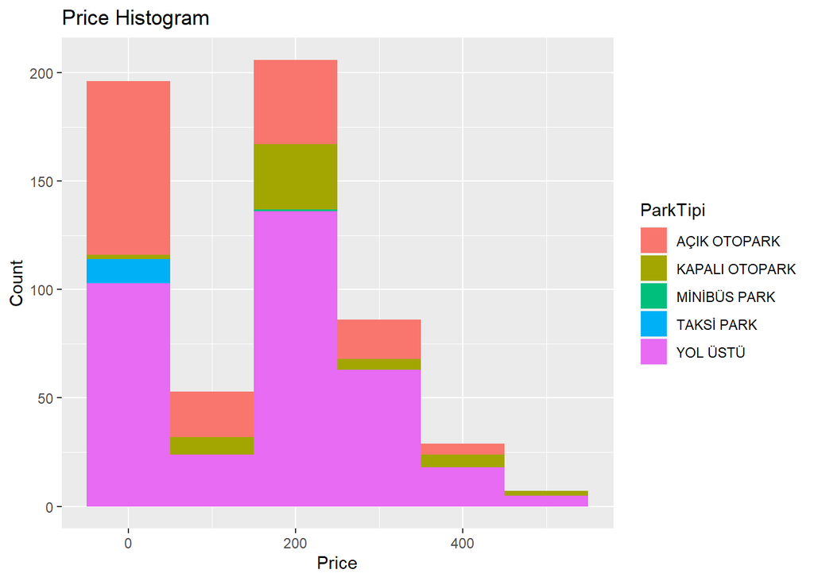